# DT-PCA

- Course: Machine Learning
- Project: 01
- Team members
- Mauro Travieso Pena
- Quoc Huy Luong
- Ngoc Bao Tran

# Classification with Decision Tree

In this experiment, we use decision tree to classify the anmie dataset.

1. Clean and Transform Data
2. Split Training/Testing dataset
3. Run the model with 3 kind of data: Original data, Normalized data and PCA data
4. Turning the model based on the learning curve and validation curve

   **Learning Curve**
   1. Using scikit-learn method #https://scikit-learn.org/stable/modules/learning_curve.html
   2. Our method (we did it, because we want to know how learning curve method works)

   **Validation Curve**
   1. Using scikit-learn method https://scikit-learn.org/stable/modules/generated/sklearn.model_selection.validation_curve.html#sklearn.model_selection.validation_curve
   2. Our method (we did it, because we want to know how Validation curve method works)
5. Grid search CV
6. Final Evaluation

# Import Libraries

```python
import pandas as pd
import numpy as np
import random as rnd
import seaborn as sns
import matplotlib.pyplot as plt
%matplotlib inline

import import_ipynb
import functions as myLib
import myPlot as myPlotLib
```

```
importing Jupyter notebook from functions.ipynb
importing Jupyter notebook from myPlot.ipynb
```

# Load data from files

```python
RawData = pd.read_csv('../data/anime.csv')
```

#### Clean and Transform Data

```python
Cleaned_Data = myLib.myCleanAndTransformData(RawData)
Y_Data = Cleaned_Data['Class']
X_Data = Cleaned_Data.drop(columns=['Class'])
```

#### Normalize Data

```python
Normalized_Data = myLib.myNormalize(X_Data)
```

#### PCA

```python
n_components=40
PCA_Data = myLib.myPCA(Normalized_Data,n_components)
PCA_Data.head()
```

|  | 0 | 1 | 2 | 3 | 4 | 5 | 6 | 7 | 8 | 9 | ... | 30 | 31 | 32 | 33 | 34 | 35 | 36 | 37 | 38 | 39 |
| --- | --- | --- | --- | --- | --- | --- | --- | --- | --- | --- | --- | --- | --- | --- | --- | --- | --- | --- | --- | --- | --- |
| 0 | -0.311391 | 0.786561 | -0.420790 | 0.005234 | -0.078663 | -0.049646 | -0.062640 | 0.007159 | -0.075350 | -0.030939 | ... | -0.011766 | -0.014544 | 0.009624 | -0.010391 | -0.008294 | -0.003729 | 0.005158 | -0.012823 | -0.007911 | -0.003259 |
| 1 | -0.284662 | 0.764035 | -0.411982 | -0.010872 | -0.110067 | -0.087035 | -0.096786 | 0.054585 | -0.179466 | -0.045549 | ... | -0.007237 | -0.013040 | 0.006490 | -0.011267 | -0.008365 | -0.001023 | 0.008290 | -0.012455 | -0.009469 | -0.004253 |
| 2 | -0.284659 | 0.767955 | -0.395541 | -0.007615 | -0.091869 | -0.059768 | -0.062093 | 0.036484 | -0.086830 | -0.024722 | ... | -0.009480 | -0.014745 | 0.006699 | -0.012642 | -0.009994 | -0.004984 | 0.006426 | -0.014430 | -0.014064 | -0.004142 |
| 3 | -0.291422 | 0.777222 | -0.408286 | 0.000300 | -0.080828 | -0.049801 | -0.056895 | 0.019128 | -0.070776 | -0.027971 | ... | -0.012258 | -0.015443 | 0.007742 | -0.011220 | -0.009451 | -0.007478 | 0.004182 | -0.014082 | -0.012944 | -0.006351 |
| 4 | 0.731807 | -0.153182 | -0.102195 | -0.458238 | 0.816873 | 0.046188 | 0.015792 | -0.064743 | 0.014353 | -0.005003 | ... | 0.006813 | -0.013311 | 0.020575 | -0.014237 | -0.007366 | 0.028672 | 0.025019 | -0.017381 | -0.005185 | 0.063293 |

5 rows × 40 columns

#### ----------------------------------------------------------------

# Decision Tree Classification

#### ----------------------------------------------------------------

```python
Y_Data.head()
```

```
0    1
1    1
2    1
3    1
4    1
Name: Class, dtype: int64
```

```python
X_Data.head()
```

|  | members | type_Movie | type_Music | type_ONA | type_OVA | type_Special | type_TV | genre_ Adventure | genre_ Cars | genre_ Comedy | ... | genre_Shoujo | genre_Shounen | genre_Slice of Life | genre_Space | genre_Sports | genre_Super Power | genre_Supernatural | genre_Thriller | genre_Vampire | genre_Yaoi |
| --- | --- | --- | --- | --- | --- | --- | --- | --- | --- | --- | --- | --- | --- | --- | --- | --- | --- | --- | --- | --- | --- |
| 0 | 200630 | 1 | 0 | 0 | 0 | 0 | 0 | 0 | 0 | 0 | ... | 0 | 0 | 0 | 0 | 0 | 0 | 0 | 0 | 0 | 0 |
| 1 | 200630 | 1 | 0 | 0 | 0 | 0 | 0 | 0 | 0 | 0 | ... | 0 | 0 | 0 | 0 | 0 | 0 | 0 | 0 | 0 | 0 |
| 2 | 200630 | 1 | 0 | 0 | 0 | 0 | 0 | 0 | 0 | 0 | ... | 0 | 0 | 0 | 0 | 0 | 0 | 0 | 0 | 0 | 0 |
| 3 | 200630 | 1 | 0 | 0 | 0 | 0 | 0 | 0 | 0 | 0 | ... | 0 | 0 | 0 | 0 | 0 | 0 | 0 | 0 | 0 | 0 |
| 4 | 793665 | 0 | 0 | 0 | 0 | 0 | 1 | 0 | 0 | 0 | ... | 0 | 0 | 0 | 0 | 0 | 0 | 0 | 0 | 0 | 0 |

5 rows × 89 columns

```python
Normalized_Data.head()
```

|  | 0 | 1 | 2 | 3 | 4 | 5 | 6 | 7 | 8 | 9 | ... | 79 | 80 | 81 | 82 | 83 | 84 | 85 | 86 | 87 | 88 |
| --- | --- | --- | --- | --- | --- | --- | --- | --- | --- | --- | --- | --- | --- | --- | --- | --- | --- | --- | --- | --- | --- |
| 0 | 0.197867 | 1.0 | 0.0 | 0.0 | 0.0 | 0.0 | 0.0 | 0.0 | 0.0 | 0.0 | ... | 0.0 | 0.0 | 0.0 | 0.0 | 0.0 | 0.0 | 0.0 | 0.0 | 0.0 | 0.0 |
| 1 | 0.197867 | 1.0 | 0.0 | 0.0 | 0.0 | 0.0 | 0.0 | 0.0 | 0.0 | 0.0 | ... | 0.0 | 0.0 | 0.0 | 0.0 | 0.0 | 0.0 | 0.0 | 0.0 | 0.0 | 0.0 |
| 2 | 0.197867 | 1.0 | 0.0 | 0.0 | 0.0 | 0.0 | 0.0 | 0.0 | 0.0 | 0.0 | ... | 0.0 | 0.0 | 0.0 | 0.0 | 0.0 | 0.0 | 0.0 | 0.0 | 0.0 | 0.0 |
| 3 | 0.197867 | 1.0 | 0.0 | 0.0 | 0.0 | 0.0 | 0.0 | 0.0 | 0.0 | 0.0 | ... | 0.0 | 0.0 | 0.0 | 0.0 | 0.0 | 0.0 | 0.0 | 0.0 | 0.0 | 0.0 |
| 4 | 0.782769 | 0.0 | 0.0 | 0.0 | 0.0 | 0.0 | 1.0 | 0.0 | 0.0 | 0.0 | ... | 0.0 | 0.0 | 0.0 | 0.0 | 0.0 | 0.0 | 0.0 | 0.0 | 0.0 | 0.0 |

5 rows × 89 columns

```python
PCA_Data.head()
```

|  | 0 | 1 | 2 | 3 | 4 | 5 | 6 | 7 | 8 | 9 | ... | 30 | 31 | 32 | 33 | 34 | 35 | 36 | 37 | 38 | 39 |
| --- | --- | --- | --- | --- | --- | --- | --- | --- | --- | --- | --- | --- | --- | --- | --- | --- | --- | --- | --- | --- | --- |
| 0 | -0.311391 | 0.786561 | -0.420790 | 0.005234 | -0.078663 | -0.049646 | -0.062640 | 0.007159 | -0.075350 | -0.030939 | ... | -0.011766 | -0.014544 | 0.009624 | -0.010391 | -0.008294 | -0.003729 | 0.005158 | -0.012823 | -0.007911 | -0.003259 |
| 1 | -0.284662 | 0.764035 | -0.411982 | -0.010872 | -0.110067 | -0.087035 | -0.096786 | 0.054585 | -0.179466 | -0.045549 | ... | -0.007237 | -0.013040 | 0.006490 | -0.011267 | -0.008365 | -0.001023 | 0.008290 | -0.012455 | -0.009469 | -0.004253 |
| 2 | -0.284659 | 0.767955 | -0.395541 | -0.007615 | -0.091869 | -0.059768 | -0.062093 | 0.036484 | -0.086830 | -0.024722 | ... | -0.009480 | -0.014745 | 0.006699 | -0.012642 | -0.009994 | -0.004984 | 0.006426 | -0.014430 | -0.014064 | -0.004142 |
| 3 | -0.291422 | 0.777222 | -0.408286 | 0.000300 | -0.080828 | -0.049801 | -0.056895 | 0.019128 | -0.070776 | -0.027971 | ... | -0.012258 | -0.015443 | 0.007742 | -0.011220 | -0.009451 | -0.007478 | 0.004182 | -0.014082 | -0.012944 | -0.006351 |
| 4 | 0.731807 | -0.153182 | -0.102195 | -0.458238 | 0.816873 | 0.046188 | 0.015792 | -0.064743 | 0.014353 | -0.005003 | ... | 0.006813 | -0.013311 | 0.020575 | -0.014237 | -0.007366 | 0.028672 | 0.025019 | -0.017381 | -0.005185 | 0.063293 |

5 rows × 40 columns

#### ----------------------------------------------------------------

#### ----------------------------------------------------------------

```python
X_train, X_test, y_train, y_test  = myLib.mySplitData(X_Data,Y_Data,0.33,42)

X_train.head()
```

|  | members | type_Movie | type_Music | type_ONA | type_OVA | type_Special | type_TV | genre_ Adventure | genre_ Cars | genre_ Comedy | ... | genre_Shoujo | genre_Shounen | genre_Slice of Life | genre_Space | genre_Sports | genre_Super Power | genre_Supernatural | genre_Thriller | genre_Vampire | genre_Yaoi |
| --- | --- | --- | --- | --- | --- | --- | --- | --- | --- | --- | --- | --- | --- | --- | --- | --- | --- | --- | --- | --- | --- |
| 32729 | 132 | 0 | 0 | 0 | 0 | 1 | 0 | 0 | 0 | 0 | ... | 0 | 0 | 0 | 0 | 0 | 0 | 0 | 0 | 0 | 0 |
| 24946 | 7051 | 0 | 0 | 0 | 1 | 0 | 0 | 0 | 0 | 0 | ... | 0 | 0 | 0 | 0 | 0 | 0 | 0 | 0 | 0 | 0 |
| 8676 | 65896 | 0 | 0 | 0 | 0 | 0 | 1 | 0 | 0 | 0 | ... | 0 | 0 | 0 | 0 | 0 | 0 | 0 | 0 | 0 | 0 |
| 13244 | 67936 | 0 | 0 | 0 | 0 | 0 | 1 | 0 | 0 | 0 | ... | 0 | 0 | 0 | 0 | 0 | 0 | 0 | 0 | 0 | 0 |
| 29384 | 49 | 0 | 0 | 0 | 0 | 0 | 1 | 0 | 0 | 0 | ... | 0 | 0 | 0 | 0 | 0 | 0 | 0 | 0 | 0 | 0 |

5 rows × 89 columns

```python
X_test.head()
```

|  | members | type_Movie | type_Music | type_ONA | type_OVA | type_Special | type_TV | genre_ Adventure | genre_ Cars | genre_ Comedy | ... | genre_Shoujo | genre_Shounen | genre_Slice of Life | genre_Space | genre_Sports | genre_Super Power | genre_Supernatural | genre_Thriller | genre_Vampire | genre_Yaoi |
| --- | --- | --- | --- | --- | --- | --- | --- | --- | --- | --- | --- | --- | --- | --- | --- | --- | --- | --- | --- | --- | --- |
| 22373 | 3331 | 0 | 0 | 1 | 0 | 0 | 0 | 0 | 0 | 0 | ... | 0 | 0 | 0 | 0 | 0 | 0 | 0 | 0 | 0 | 0 |
| 10508 | 28423 | 0 | 0 | 0 | 0 | 0 | 1 | 0 | 0 | 0 | ... | 0 | 0 | 0 | 0 | 0 | 0 | 0 | 0 | 0 | 0 |
| 11570 | 5078 | 1 | 0 | 0 | 0 | 0 | 0 | 0 | 0 | 0 | ... | 0 | 0 | 0 | 0 | 0 | 0 | 0 | 0 | 0 | 0 |
| 22262 | 390 | 1 | 0 | 0 | 0 | 0 | 0 | 0 | 0 | 0 | ... | 0 | 0 | 0 | 0 | 0 | 0 | 0 | 0 | 0 | 0 |
| 734 | 482268 | 0 | 0 | 0 | 0 | 0 | 1 | 0 | 0 | 0 | ... | 0 | 0 | 0 | 0 | 0 | 0 | 0 | 0 | 0 | 0 |

5 rows × 89 columns

```python
y_train.head()
```

```
32729    1
24946    0
8676     1
13244    1
29384    1
Name: Class, dtype: int64
```

```python
y_test.head()
```

```
22373    0
10508    1
11570    1
22262    0
734      1
Name: Class, dtype: int64
```

#### ----------------------------------------------------------------

#### Split Original Normalized_Data

#### ----------------------------------------------------------------

```python
Normalized_X_train, Normalized_X_test, Normalized_y_train, Normalized_y_test  = myLib.mySplitData(Normalized_Data,Y_Data,0.33,42)

Normalized_X_train.head()
```

|  | 0 | 1 | 2 | 3 | 4 | 5 | 6 | 7 | 8 | 9 | ... | 79 | 80 | 81 | 82 | 83 | 84 | 85 | 86 | 87 | 88 |
| --- | --- | --- | --- | --- | --- | --- | --- | --- | --- | --- | --- | --- | --- | --- | --- | --- | --- | --- | --- | --- | --- |
| 32729 | 0.000118 | 0.0 | 0.0 | 0.0 | 0.0 | 1.0 | 0.0 | 0.0 | 0.0 | 0.0 | ... | 0.0 | 0.0 | 0.0 | 0.0 | 0.0 | 0.0 | 0.0 | 0.0 | 0.0 | 0.0 |
| 24946 | 0.006942 | 0.0 | 0.0 | 0.0 | 1.0 | 0.0 | 0.0 | 0.0 | 0.0 | 0.0 | ... | 0.0 | 0.0 | 0.0 | 0.0 | 0.0 | 0.0 | 0.0 | 0.0 | 0.0 | 0.0 |
| 8676 | 0.064980 | 0.0 | 0.0 | 0.0 | 0.0 | 0.0 | 1.0 | 0.0 | 0.0 | 0.0 | ... | 0.0 | 0.0 | 0.0 | 0.0 | 0.0 | 0.0 | 0.0 | 0.0 | 0.0 | 0.0 |
| 13244 | 0.066992 | 0.0 | 0.0 | 0.0 | 0.0 | 0.0 | 1.0 | 0.0 | 0.0 | 0.0 | ... | 0.0 | 0.0 | 0.0 | 0.0 | 0.0 | 0.0 | 0.0 | 0.0 | 0.0 | 0.0 |
| 29384 | 0.000036 | 0.0 | 0.0 | 0.0 | 0.0 | 0.0 | 1.0 | 0.0 | 0.0 | 0.0 | ... | 0.0 | 0.0 | 0.0 | 0.0 | 0.0 | 0.0 | 0.0 | 0.0 | 0.0 | 0.0 |

5 rows × 89 columns

```python
Normalized_X_test.head()
```

|  | 0 | 1 | 2 | 3 | 4 | 5 | 6 | 7 | 8 | 9 | ... | 79 | 80 | 81 | 82 | 83 | 84 | 85 | 86 | 87 | 88 |
| --- | --- | --- | --- | --- | --- | --- | --- | --- | --- | --- | --- | --- | --- | --- | --- | --- | --- | --- | --- | --- | --- |
| 22373 | 0.003273 | 0.0 | 0.0 | 1.0 | 0.0 | 0.0 | 0.0 | 0.0 | 0.0 | 0.0 | ... | 0.0 | 0.0 | 0.0 | 0.0 | 0.0 | 0.0 | 0.0 | 0.0 | 0.0 | 0.0 |
| 10508 | 0.028021 | 0.0 | 0.0 | 0.0 | 0.0 | 0.0 | 1.0 | 0.0 | 0.0 | 0.0 | ... | 0.0 | 0.0 | 0.0 | 0.0 | 0.0 | 0.0 | 0.0 | 0.0 | 0.0 | 0.0 |
| 11570 | 0.004997 | 1.0 | 0.0 | 0.0 | 0.0 | 0.0 | 0.0 | 0.0 | 0.0 | 0.0 | ... | 0.0 | 0.0 | 0.0 | 0.0 | 0.0 | 0.0 | 0.0 | 0.0 | 0.0 | 0.0 |
| 22262 | 0.000373 | 1.0 | 0.0 | 0.0 | 0.0 | 0.0 | 0.0 | 0.0 | 0.0 | 0.0 | ... | 0.0 | 0.0 | 0.0 | 0.0 | 0.0 | 0.0 | 0.0 | 0.0 | 0.0 | 0.0 |
| 734 | 0.475642 | 0.0 | 0.0 | 0.0 | 0.0 | 0.0 | 1.0 | 0.0 | 0.0 | 0.0 | ... | 0.0 | 0.0 | 0.0 | 0.0 | 0.0 | 0.0 | 0.0 | 0.0 | 0.0 | 0.0 |

5 rows × 89 columns

```python
Normalized_y_train.head()
```

```
32729    1
24946    0
8676     1
13244    1
29384    1
Name: Class, dtype: int64
```

```python
Normalized_y_test.head()
```

```
22373    0
10508    1
11570    1
22262    0
734      1
Name: Class, dtype: int64
```

#### ----------------------------------------------------------------

#### ----------------------------------------------------------------

```python
PCA_X_train, PCA_X_test, PCA_y_train, PCA_y_test  = myLib.mySplitData(PCA_Data,Y_Data,0.33,42)

PCA_X_train.head()
```

|  | 0 | 1 | 2 | 3 | 4 | 5 | 6 | 7 | 8 | 9 | ... | 30 | 31 | 32 | 33 | 34 | 35 | 36 | 37 | 38 | 39 |
| --- | --- | --- | --- | --- | --- | --- | --- | --- | --- | --- | --- | --- | --- | --- | --- | --- | --- | --- | --- | --- | --- |
| 32729 | -0.222410 | 0.292968 | 0.905577 | -0.156240 | -0.108038 | -0.031218 | -0.020906 | 0.049072 | -0.031243 | 0.007778 | ... | -0.432539 | -0.042734 | 0.027203 | -0.022899 | 0.006603 | 0.055185 | 0.051851 | 0.071091 | 0.304861 | -0.228760 |
| 24946 | -0.645218 | -0.558932 | -0.134425 | -0.006471 | -0.054637 | -0.037266 | -0.023106 | -0.012107 | -0.029795 | 0.004538 | ... | 0.049424 | 0.042383 | -0.037793 | -0.002981 | 0.012007 | 0.350940 | 0.801683 | -0.404001 | -0.204172 | -0.087199 |
| 8676 | 0.697428 | -0.148271 | -0.076755 | -0.039170 | -0.073629 | -0.033199 | -0.020331 | 0.015741 | -0.034394 | -0.002522 | ... | 0.146139 | 0.198325 | -0.365057 | -0.068155 | 0.856704 | -0.128124 | -0.056864 | -0.036336 | -0.036075 | -0.022665 |
| 13244 | 0.703994 | -0.156393 | -0.072758 | -0.051336 | -0.099958 | -0.053601 | -0.030918 | 0.052111 | -0.056604 | -0.005999 | ... | -0.012918 | -0.004194 | 0.003532 | -0.000357 | -0.002382 | -0.014037 | -0.011255 | -0.002197 | -0.002189 | -0.006810 |
| 29384 | 0.702822 | -0.120081 | -0.090825 | -0.060693 | -0.137073 | -0.101899 | -0.122610 | 0.067887 | -0.325710 | 0.726579 | ... | -0.006901 | -0.000092 | 0.001829 | 0.001893 | 0.000042 | -0.009652 | -0.009893 | 0.000587 | -0.000187 | -0.002036 |

5 rows × 40 columns

```python
PCA_X_test.head()
```

|  | 0 | 1 | 2 | 3 | 4 | 5 | 6 | 7 | 8 | 9 | ... | 30 | 31 | 32 | 33 | 34 | 35 | 36 | 37 | 38 | 39 |
| --- | --- | --- | --- | --- | --- | --- | --- | --- | --- | --- | --- | --- | --- | --- | --- | --- | --- | --- | --- | --- | --- |
| 22373 | -0.124203 | 0.125895 | 0.130241 | 0.040248 | -0.039136 | 0.017932 | 0.271853 | 0.949263 | 0.306449 | -0.021895 | ... | -0.019535 | -0.022859 | 0.030717 | 0.021098 | 0.014113 | -0.014109 | 0.001116 | -0.008907 | -0.003808 | -0.011636 |
| 10508 | 0.709233 | -0.165356 | -0.059587 | -0.058864 | -0.111087 | -0.063255 | -0.035980 | 0.070086 | -0.072611 | -0.002226 | ... | -0.010653 | -0.002649 | 0.001348 | -0.001033 | -0.002555 | -0.013234 | -0.010658 | -0.001511 | -0.002888 | -0.007952 |
| 11570 | -0.302989 | 0.781850 | -0.421044 | -0.036603 | -0.226477 | 0.908892 | 0.064898 | -0.181633 | 0.053341 | -0.011209 | ... | -0.006011 | -0.006198 | -0.000417 | -0.007843 | -0.006043 | -0.004755 | 0.002186 | -0.005710 | -0.004625 | -0.016087 |
| 22262 | -0.292379 | 0.765577 | -0.409821 | -0.008916 | -0.110511 | -0.085449 | -0.096096 | 0.057723 | -0.179229 | -0.042895 | ... | -0.009831 | -0.008746 | 0.000710 | -0.007486 | -0.006497 | -0.009594 | -0.000055 | -0.007219 | -0.007334 | -0.021241 |
| 734 | 0.719961 | -0.159583 | -0.077230 | -0.055383 | -0.099040 | -0.056883 | -0.032346 | 0.045618 | -0.057094 | -0.011492 | ... | -0.007551 | -0.013078 | 0.015492 | -0.008181 | -0.006248 | 0.003698 | 0.006013 | -0.013032 | -0.006608 | 0.028341 |

5 rows × 40 columns

```python
PCA_y_train.head()
```

```
32729    1
24946    0
8676     1
13244    1
29384    1
Name: Class, dtype: int64
```

```python
PCA_y_test.head()
```

```
22373    0
10508    1
11570    1
22262    0
734      1
Name: Class, dtype: int64
```

#### ----------------------------------------------------------------

# Model Training

#### ----------------------------------------------------------------

```python
from sklearn.model_selection import cross_val_score
from sklearn.tree import DecisionTreeClassifier

def myDT(clf,X_train,y_train,X_test,y_test,cv):
    #Fit the model
    #The maximum depth of the tree.
    #If None, then nodes are expanded until all leaves are pure
    # or until all leaves contain less than min_samples_split samples.
    #min_samples_split: by default = 1
    clf.fit(X_train, y_train)
    #check accuracy of model on the train and test data
    train_score = clf.score(X_train, y_train)
    test_score = clf.score(X_test, y_test)
    #Using CV
    cv_scores = cross_val_score(clf, X_train, y_train, cv=cv)
    return pd.DataFrame({"leaves":[clf.get_n_leaves()],"depth":[clf.get_depth()],"train_score":[train_score],"test_score":[test_score],"cv_score":[cv_scores.mean()]})
```

```python
def myDT_ModelTurning(clf,depths,X_train,y_train,X_test,y_test,cv):
    df = pd.DataFrame({"depth":[],"train_score":[],"cv_score":[]})
    for depth in depths:
        clf1 = DecisionTreeClassifier(max_depth=depth,random_state=0)
        score_df = myDT(clf1,X_train,y_train,X_test,y_test,cv)
        df = df.append(pd.DataFrame({"depth":depth,"train_score":score_df.train_score,"test_score":score_df.test_score,"cv_score":score_df.cv_score}),ignore_index=True,sort=False)

    return df
```

```python
cv = 10
clf = DecisionTreeClassifier(random_state=0)
```

```python
#Original Data
scores = myDT(clf,X_train,y_train,X_test,y_test,cv)
scores
```

|  | leaves | depth | train_score | test_score | cv_score |
| --- | --- | --- | --- | --- | --- |
| 0 | 4456 | 44 | 0.988382 | 0.821124 | 0.815258 |

```python
#Normalized Data
scores = myDT(clf,Normalized_X_train,Normalized_y_train,Normalized_X_test,Normalized_y_test,cv)
scores
```

|  | leaves | depth | train_score | test_score | cv_score |
| --- | --- | --- | --- | --- | --- |
| 0 | 4456 | 44 | 0.988382 | 0.820866 | 0.8153 |

```python
#PCA Data
scores = myDT(clf,PCA_X_train,PCA_y_train,PCA_X_test,PCA_y_test,cv)
scores
```

|  | leaves | depth | train_score | test_score | cv_score |
| --- | --- | --- | --- | --- | --- |
| 0 | 5629 | 60 | 0.974771 | 0.751485 | 0.745549 |

```python
X_Data = PCA_Data
X_train = PCA_X_train
X_test = PCA_X_test
y_train = PCA_y_train
y_test = PCA_y_test
```

#### ----------------------------------------------------------------

# Learning Curve

#### ----------------------------------------------------------------

# https://scikit-learn.org/stable/modules/learning_curve.html

```python
from sklearn.model_selection import learning_curve
splitsSize = np.linspace(0.04,0.99,20)
splitsSize
```

```
array([0.04, 0.09, 0.14, 0.19, 0.24, 0.29, 0.34, 0.39, 0.44, 0.49, 0.54,
       0.59, 0.64, 0.69, 0.74, 0.79, 0.84, 0.89, 0.94, 0.99])
```

```python
train_sizes, train_scores, test_scores = learning_curve(
        clf, X_Data, Y_Data, cv=cv, n_jobs=1, train_sizes=splitsSize)
```

```python
train_sizes
```

```
array([ 1267,  2851,  4435,  6019,  7603,  9187, 10771, 12355, 13939,
       15523, 17107, 18691, 20275, 21859, 23443, 25027, 26611, 28195,
       29779, 31363])
```

```python
train_scores
```

```
array([[1.        , 1.        , 1.        , 1.        , 1.        ,
        1.        , 1.        , 1.        , 1.        , 1.        ],
       [1.        , 1.        , 1.        , 1.        , 1.        ,
        1.        , 1.        , 1.        , 1.        , 1.        ],
       [1.        , 1.        , 1.        , 1.        , 1.        ,
        1.        , 1.        , 1.        , 1.        , 1.        ],
       [1.        , 1.        , 1.        , 1.        , 1.        ,
        1.        , 1.        , 1.        , 1.        , 1.        ],
       [1.        , 1.        , 1.        , 1.        , 1.        ,
        1.        , 1.        , 1.        , 1.        , 1.        ],
       [1.        , 1.        , 1.        , 1.        , 1.        ,
        1.        , 1.        , 1.        , 1.        , 1.        ],
       [1.        , 1.        , 1.        , 1.        , 1.        ,
        1.        , 1.        , 1.        , 1.        , 1.        ],
       [1.        , 1.        , 1.        , 1.        , 1.        ,
        1.        , 1.        , 1.        , 1.        , 1.        ],
       [1.        , 1.        , 1.        , 1.        , 1.        ,
        1.        , 1.        , 1.        , 1.        , 1.        ],
       [1.        , 1.        , 1.        , 1.        , 1.        ,
        1.        , 1.        , 1.        , 1.        , 1.        ],
       [1.        , 1.        , 1.        , 1.        , 1.        ,
        1.        , 1.        , 1.        , 1.        , 1.        ],
       [0.99860896, 0.99866246, 0.99855545, 0.99855545, 0.99855545,
        0.99887646, 0.99871596, 0.99892997, 0.99887646, 1.        ],
       [0.99521578, 0.99506782, 0.99477189, 0.99482121, 0.99516646,
        0.99551171, 0.99556104, 0.995709  , 0.99664612, 1.        ],
       [0.99368681, 0.99354957, 0.99313784, 0.99254312, 0.9929091 ,
        0.99354957, 0.99382405, 0.99373256, 0.99519649, 0.99634018],
       [0.99236446, 0.99227915, 0.99189524, 0.99129804, 0.99189524,
        0.99244977, 0.99279103, 0.99266306, 0.99398541, 0.99381478],
       [0.9900907 , 0.98985096, 0.98961122, 0.98893195, 0.98957126,
        0.99084988, 0.99168898, 0.99188876, 0.99308747, 0.99248811],
       [0.9825636 , 0.98233813, 0.98199992, 0.98124836, 0.98211266,
        0.98380369, 0.98688512, 0.9888392 , 0.99004171, 0.99124422],
       [0.97492463, 0.97481823, 0.97435716, 0.97364781, 0.97442809,
        0.97613052, 0.97942898, 0.97996099, 0.98208902, 0.99060117],
       [0.96735955, 0.96732597, 0.96688942, 0.9662178 , 0.966923  ,
        0.96880352, 0.97196011, 0.97232949, 0.97300111, 0.99093321],
       [0.96728629, 0.96731818, 0.96690368, 0.96626598, 0.96680802,
        0.96865734, 0.9716545 , 0.97216465, 0.97238785, 0.99129548]])
```

```python
test_scores
```

```
array([[0.64385118, 0.64385118, 0.64385118, 0.64375   , 0.64375   ,
        0.64375   , 0.64375   , 0.64375   , 0.64393294, 0.64393294],
       [0.64385118, 0.64385118, 0.64385118, 0.64375   , 0.64375   ,
        0.64375   , 0.64375   , 0.64375   , 0.64393294, 0.64393294],
       [0.64385118, 0.64385118, 0.64385118, 0.64375   , 0.64375   ,
        0.64375   , 0.64375   , 0.64375   , 0.64393294, 0.64393294],
       [0.64385118, 0.64385118, 0.64385118, 0.64375   , 0.64375   ,
        0.64375   , 0.64375   , 0.64375   , 0.64393294, 0.64393294],
       [0.64385118, 0.64385118, 0.64385118, 0.64375   , 0.64375   ,
        0.64375   , 0.64375   , 0.64375   , 0.64393294, 0.64393294],
       [0.64385118, 0.64385118, 0.64385118, 0.64375   , 0.64375   ,
        0.64375   , 0.64375   , 0.64375   , 0.64393294, 0.64393294],
       [0.64385118, 0.64385118, 0.64385118, 0.64375   , 0.64375   ,
        0.64375   , 0.64375   , 0.64375   , 0.64393294, 0.64393294],
       [0.64385118, 0.64385118, 0.64385118, 0.64375   , 0.64375   ,
        0.64375   , 0.64375   , 0.64375   , 0.64393294, 0.64393294],
       [0.64385118, 0.64385118, 0.64385118, 0.64375   , 0.64375   ,
        0.64375   , 0.64375   , 0.64375   , 0.64393294, 0.64393294],
       [0.64385118, 0.64385118, 0.64385118, 0.64375   , 0.64375   ,
        0.64375   , 0.64375   , 0.64375   , 0.64393294, 0.64393294],
       [0.64385118, 0.64385118, 0.64385118, 0.64375   , 0.64375   ,
        0.64375   , 0.64375   , 0.64375   , 0.64393294, 0.64393294],
       [0.66429991, 0.65947174, 0.66202783, 0.66903409, 0.68352273,
        0.68607955, 0.65454545, 0.63551136, 0.66211992, 0.64393294],
       [0.71258165, 0.71030957, 0.71229764, 0.715625  , 0.72926136,
        0.75113636, 0.73863636, 0.72130682, 0.75731742, 0.64393294],
       [0.74211872, 0.73700653, 0.75120704, 0.75170455, 0.765625  ,
        0.78153409, 0.78011364, 0.75454545, 0.73770958, 0.54703041],
       [0.75915933, 0.75120704, 0.76625959, 0.77272727, 0.778125  ,
        0.79318182, 0.78409091, 0.75369318, 0.7163967 , 0.54646206],
       [0.76057938, 0.75262709, 0.76540755, 0.77585227, 0.78522727,
        0.78039773, 0.78352273, 0.75653409, 0.7104291 , 0.37396988],
       [0.75915933, 0.75035501, 0.76512354, 0.77443182, 0.77954545,
        0.77954545, 0.71363636, 0.74801136, 0.6894004 , 0.34526854],
       [0.75631923, 0.74865095, 0.76569156, 0.77642045, 0.78153409,
        0.77840909, 0.72329545, 0.70994318, 0.67689685, 0.30718954],
       [0.76285146, 0.75120704, 0.7665436 , 0.775     , 0.78011364,
        0.77840909, 0.74034091, 0.71448864, 0.65359477, 0.37737994],
       [0.76086339, 0.75234308, 0.76824766, 0.78011364, 0.78267045,
        0.78039773, 0.74289773, 0.71590909, 0.65643649, 0.35919295]])
```

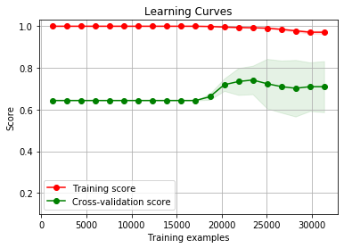

```python
title = "Learning Curves"
myPlotLib.plot_learning_curve(clf, title, X_Data, Y_Data, ylim=(0.1, 1.03),train_sizes=splitsSize, cv=cv, n_jobs=4)
plt.show()
```

```python
def myDT_LearningCurve(clf,X_Data,Y_Data,splits,cv):
    df = pd.DataFrame({"percent":[],"train_score":[],"test_score":[],"cv_score":[]})
    for X in splits:
        X_train, X_test, y_train, y_test  = myLib.mySplitDataByTrainSize(X_Data,Y_Data,X,42)
        score_df = myDT(clf,X_train,y_train,X_test,y_test,cv)
        df = df.append(pd.DataFrame({"percent":X,"train_score":score_df.train_score,"test_score":score_df.test_score,"cv_score":score_df.cv_score}),ignore_index=True,sort=False)
    return df
```

```python
learning_df= myDT_LearningCurve(clf,X_Data,Y_Data,splitsSize,cv)
learning_df
```

|  | percent | train_score | test_score | cv_score |
| --- | --- | --- | --- | --- |
| 0 | 0.04 | 0.997879 | 0.696774 | 0.683987 |
| 1 | 0.09 | 0.995759 | 0.711281 | 0.714902 |
| 2 | 0.14 | 0.993638 | 0.721573 | 0.748873 |
| 3 | 0.19 | 0.993080 | 0.730525 | 0.740829 |
| 4 | 0.24 | 0.990989 | 0.738164 | 0.745220 |
| 5 | 0.29 | 0.990057 | 0.746512 | 0.741636 |
| 6 | 0.34 | 0.986904 | 0.742785 | 0.744579 |
| 7 | 0.39 | 0.985647 | 0.737806 | 0.740238 |
| 8 | 0.44 | 0.985254 | 0.737872 | 0.741808 |
| 9 | 0.49 | 0.983385 | 0.741743 | 0.738231 |
| 10 | 0.54 | 0.982332 | 0.743185 | 0.740241 |
| 11 | 0.59 | 0.979876 | 0.742486 | 0.740262 |
| 12 | 0.64 | 0.980256 | 0.740282 | 0.744516 |
| 13 | 0.69 | 0.979412 | 0.739271 | 0.747297 |
| 14 | 0.74 | 0.979143 | 0.746161 | 0.747192 |
| 15 | 0.79 | 0.979013 | 0.748720 | 0.742633 |
| 16 | 0.84 | 0.977839 | 0.740111 | 0.746894 |
| 17 | 0.89 | 0.978513 | 0.739627 | 0.744582 |
| 18 | 0.94 | 0.975866 | 0.751190 | 0.746618 |
| 19 | 0.99 | 0.976144 | 0.742609 | 0.748972 |

```python
learning_df.describe()
```

|  | percent | train_score | test_score | cv_score |
| --- | --- | --- | --- | --- |
| count | 20.000000 | 20.000000 | 20.000000 | 20.000000 |
| mean | 0.515000 | 0.984549 | 0.736934 | 0.739475 |
| std | 0.295804 | 0.006875 | 0.013106 | 0.014910 |
| min | 0.040000 | 0.975866 | 0.696774 | 0.683987 |
| 25% | 0.277500 | 0.979110 | 0.737855 | 0.740257 |
| 50% | 0.515000 | 0.982859 | 0.740197 | 0.743575 |
| 75% | 0.752500 | 0.990290 | 0.742885 | 0.746687 |
| max | 0.990000 | 0.997879 | 0.751190 | 0.748972 |

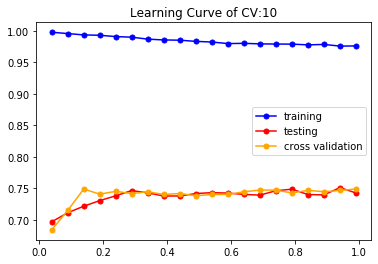

```python
fig, ax = plt.subplots()
plt.plot(learning_df.percent, learning_df.train_score, color='blue', marker='o', markersize=5, label='training')

plt.plot(learning_df.percent, learning_df.test_score, color='red', marker='o', markersize=5, label='testing')

plt.plot(learning_df.percent, learning_df.cv_score, color='orange', marker='o', markersize=5, label='cross validation')

ax.legend()
ax.set_title("Learning Curve of CV:10")
```

#### ----------------------------------------------------------------

# Validation Curve

#### ----------------------------------------------------------------

```python
depths = [1,2,4, 5, 8,10,15, 20,25,30,35,40,50,60,70,80,90,100,150,200]
```

```python
#https://scikit-learn.org/stable/modules/generated/sklearn.model_selection.validation_curve.html#sklearn.model_selection.validation_curve
from sklearn.model_selection import validation_curve
train_scores, valid_scores = validation_curve(DecisionTreeClassifier(),X_train, y_train,
    param_name="max_depth", param_range=depths,
    cv=cv, n_jobs=1)
```

```python
train_scores
```

```
array([[0.64243309, 0.64244994, 0.64244994, 0.64241967, 0.64241967,
        0.64241967, 0.64241967, 0.64241967, 0.64241967, 0.64241967],
       [0.67711082, 0.67783274, 0.67797409, 0.6753981 , 0.67751814,
        0.67487986, 0.67563366, 0.67780081, 0.67506831, 0.67798926],
       [0.70735959, 0.70468787, 0.70464075, 0.6992839 , 0.70470178,
        0.70423066, 0.7024404 , 0.70390088, 0.70145105, 0.70328842],
       [0.72413306, 0.71811543, 0.71222615, 0.7200603 , 0.71370018,
        0.71365307, 0.71176859, 0.71313483, 0.71266371, 0.71935362],
       [0.75965888, 0.75255595, 0.74779741, 0.77235466, 0.74257985,
        0.74540658, 0.74606615, 0.74540658, 0.74865731, 0.75793838],
       [0.79523181, 0.78153121, 0.78011779, 0.80943183, 0.76929238,
        0.76900971, 0.77320268, 0.76396872, 0.77847922, 0.78319043],
       [0.86736713, 0.86219081, 0.85055359, 0.87105437, 0.85060775,
        0.86050127, 0.85437671, 0.85673231, 0.85607274, 0.85461227],
       [0.92065586, 0.91274441, 0.90327444, 0.91614058, 0.90728352,
        0.91011024, 0.90544615, 0.90506925, 0.91223028, 0.90879111],
       [0.95076329, 0.94595995, 0.93837456, 0.94436069, 0.94054462,
        0.94096862, 0.93908414, 0.93668143, 0.94374823, 0.94403091],
       [0.96565209, 0.96259128, 0.95990577, 0.95953076, 0.95609159,
        0.9588712 , 0.9588712 , 0.95858852, 0.95920098, 0.96141525],
       [0.9725311 , 0.97163722, 0.97074205, 0.9686705 , 0.96414774,
        0.9671158 , 0.96716291, 0.9682936 , 0.96688024, 0.96951852],
       [0.97413306, 0.9742285 , 0.97550059, 0.97309903, 0.96791671,
        0.96989541, 0.97097899, 0.97272213, 0.97126166, 0.97366437],
       [0.9751225 , 0.97611307, 0.97705536, 0.97578442, 0.97215679,
        0.97300481, 0.97385282, 0.97630265, 0.9757373 , 0.97601998],
       [0.97559367, 0.97648999, 0.97705536, 0.9761142 , 0.97470084,
        0.97451239, 0.97512485, 0.97663243, 0.97644398, 0.9761142 ],
       [0.97592348, 0.97672556, 0.97705536, 0.9761142 , 0.97517196,
        0.97587864, 0.97540752, 0.97663243, 0.97653821, 0.9761142 ],
       [0.97592348, 0.97672556, 0.97705536, 0.9761142 , 0.97578442,
        0.97663243, 0.97540752, 0.97663243, 0.97653821, 0.9761142 ],
       [0.97592348, 0.97672556, 0.97705536, 0.9761142 , 0.97578442,
        0.97663243, 0.97540752, 0.97663243, 0.97653821, 0.9761142 ],
       [0.97592348, 0.97672556, 0.97705536, 0.9761142 , 0.97578442,
        0.97663243, 0.97540752, 0.97663243, 0.97653821, 0.9761142 ],
       [0.97592348, 0.97672556, 0.97705536, 0.9761142 , 0.97578442,
        0.97663243, 0.97540752, 0.97663243, 0.97653821, 0.9761142 ],
       [0.97592348, 0.97672556, 0.97705536, 0.9761142 , 0.97578442,
        0.97663243, 0.97540752, 0.97663243, 0.97653821, 0.9761142 ]])
```

```python
valid_scores
```

```
array([[0.64237288, 0.64222128, 0.64222128, 0.64249364, 0.64249364,
        0.64249364, 0.64249364, 0.64249364, 0.64249364, 0.64249364],
       [0.66016949, 0.67952522, 0.67867741, 0.67599661, 0.67387617,
        0.6798134 , 0.67133164, 0.67938931, 0.67684478, 0.67302799],
       [0.67669492, 0.69605765, 0.70284019, 0.68617472, 0.71034775,
        0.70780322, 0.69126378, 0.70992366, 0.70525869, 0.68787108],
       [0.69025424, 0.71131836, 0.71682916, 0.71458863, 0.71416455,
        0.71670908, 0.70780322, 0.71034775, 0.71882952, 0.69635284],
       [0.71991525, 0.73208987, 0.71513353, 0.74512299, 0.72985581,
        0.73791349, 0.72052587, 0.72943172, 0.72815946, 0.71967769],
       [0.74491525, 0.74268758, 0.74226367, 0.76802375, 0.73833757,
        0.74978796, 0.7408821 , 0.74045802, 0.74893978, 0.73791349],
       [0.77372881, 0.76727427, 0.77617635, 0.76929601, 0.77608142,
        0.77650551, 0.77141645, 0.7735369 , 0.77099237, 0.76378287],
       [0.75338983, 0.76642645, 0.76176346, 0.77268872, 0.77862595,
        0.77056828, 0.78329092, 0.7663274 , 0.7697201 , 0.76802375],
       [0.74533898, 0.75328529, 0.75201357, 0.76547922, 0.76675148,
        0.76039016, 0.77099237, 0.75402884, 0.75402884, 0.75784563],
       [0.7440678 , 0.74565494, 0.74904621, 0.75742154, 0.76039016,
        0.75657337, 0.7625106 , 0.75021204, 0.74597116, 0.7519084 ],
       [0.73644068, 0.73972022, 0.74565494, 0.75742154, 0.76039016,
        0.75360475, 0.76166243, 0.74724343, 0.74681934, 0.74597116],
       [0.73728814, 0.7388724 , 0.74480712, 0.75360475, 0.75233249,
        0.75233249, 0.75954198, 0.74427481, 0.7446989 , 0.74597116],
       [0.73601695, 0.74056804, 0.74438321, 0.75445293, 0.75360475,
        0.74936387, 0.75784563, 0.74427481, 0.7408821 , 0.74427481],
       [0.73601695, 0.73802459, 0.7439593 , 0.75487701, 0.75318066,
        0.7480916 , 0.75657337, 0.74300254, 0.7408821 , 0.74300254],
       [0.73559322, 0.73760068, 0.7435354 , 0.75402884, 0.7553011 ,
        0.7480916 , 0.75699746, 0.74342663, 0.7408821 , 0.74385072],
       [0.73686441, 0.73972022, 0.74311149, 0.75487701, 0.75233249,
        0.7480916 , 0.75614928, 0.74215437, 0.74130619, 0.7446989 ],
       [0.73559322, 0.7384485 , 0.74565494, 0.75487701, 0.75148431,
        0.74597116, 0.75742154, 0.74385072, 0.7408821 , 0.74512299],
       [0.73474576, 0.7388724 , 0.74438321, 0.7553011 , 0.75318066,
        0.7480916 , 0.75742154, 0.74045802, 0.74045802, 0.74427481],
       [0.73559322, 0.74014413, 0.74523103, 0.75402884, 0.75318066,
        0.7480916 , 0.75784563, 0.74173028, 0.74003393, 0.74385072],
       [0.73559322, 0.74014413, 0.7439593 , 0.75445293, 0.75318066,
        0.74893978, 0.75614928, 0.74300254, 0.7408821 , 0.7446989 ]])
```

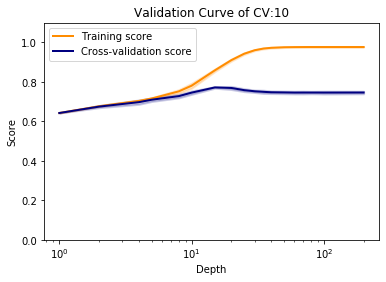

```python
train_scores_mean = np.mean(train_scores, axis=1)
train_scores_std = np.std(train_scores, axis=1)
valid_scores_mean = np.mean(valid_scores, axis=1)
valid_scores_std = np.std(valid_scores, axis=1)

plt.title("Validation Curve of CV:10")
plt.xlabel("Depth")
plt.ylabel("Score")
plt.ylim(0.0, 1.1)
lw = 2
plt.semilogx(depths, train_scores_mean, label="Training score",
             color="darkorange", lw=lw)
plt.fill_between(depths, train_scores_mean - train_scores_std,
                 train_scores_mean + train_scores_std, alpha=0.2,
                 color="darkorange", lw=lw)
plt.semilogx(depths, valid_scores_mean, label="Cross-validation score",
             color="navy", lw=lw)
plt.fill_between(depths, valid_scores_mean - valid_scores_std,
                 valid_scores_mean + valid_scores_std, alpha=0.2,
                 color="navy", lw=lw)
plt.legend(loc="best")
plt.show()
```

#### ----------------------------------------------------------------

# Model Turning

#### ----------------------------------------------------------------

```python
learnig_df= myDT_ModelTurning(clf,depths,X_train,y_train,X_test,y_test,cv)
learnig_df
```

|  | depth | train_score | cv_score | test_score |
| --- | --- | --- | --- | --- |
| 0 | 1.0 | 0.642427 | 0.642427 | 0.646639 |
| 1 | 2.0 | 0.677154 | 0.674865 | 0.677542 |
| 2 | 4.0 | 0.704418 | 0.697424 | 0.701386 |
| 3 | 5.0 | 0.713619 | 0.709677 | 0.711457 |
| 4 | 8.0 | 0.746141 | 0.727571 | 0.730998 |
| 5 | 10.0 | 0.769590 | 0.745379 | 0.745545 |
| 6 | 15.0 | 0.853672 | 0.771879 | 0.782216 |
| 7 | 20.0 | 0.906759 | 0.768828 | 0.774296 |
| 8 | 25.0 | 0.942461 | 0.758354 | 0.764139 |
| 9 | 30.0 | 0.960482 | 0.751952 | 0.760265 |
| 10 | 35.0 | 0.968241 | 0.749578 | 0.756908 |
| 11 | 40.0 | 0.971464 | 0.747373 | 0.754928 |
| 12 | 50.0 | 0.974347 | 0.746736 | 0.751054 |
| 13 | 60.0 | 0.974771 | 0.745846 | 0.751485 |
| 14 | 70.0 | 0.974771 | 0.745761 | 0.751485 |
| 15 | 80.0 | 0.974771 | 0.745507 | 0.751485 |
| 16 | 90.0 | 0.974771 | 0.745549 | 0.751485 |
| 17 | 100.0 | 0.974771 | 0.745549 | 0.751485 |
| 18 | 150.0 | 0.974771 | 0.745549 | 0.751485 |
| 19 | 200.0 | 0.974771 | 0.745549 | 0.751485 |

```python
learnig_df.describe()
```

|  | depth | train_score | cv_score | test_score |
| --- | --- | --- | --- | --- |
| count | 20.000000 | 20.000000 | 20.000000 | 20.000000 |
| mean | 49.750000 | 0.882709 | 0.735568 | 0.740888 |
| std | 53.155061 | 0.122640 | 0.031644 | 0.032867 |
| min | 1.000000 | 0.642427 | 0.642427 | 0.646639 |
| 25% | 9.500000 | 0.763728 | 0.740927 | 0.741908 |
| 50% | 32.500000 | 0.964361 | 0.745549 | 0.751485 |
| 75% | 72.500000 | 0.974771 | 0.747924 | 0.755423 |
| max | 200.000000 | 0.974771 | 0.771879 | 0.782216 |

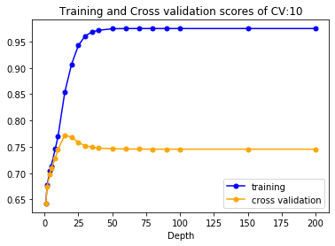

```python
fig,ax = plt.subplots()
plt.xlabel("Depth")
plt.plot(learnig_df.depth, learnig_df.train_score, color='blue', marker='o', markersize=5, label='training')
plt.plot(learnig_df.depth, learnig_df.cv_score, color='orange', marker='o', markersize=5, label='cross validation')

ax.legend()
ax.set_title("Training and Cross validation scores of CV:10")
```

That means, the best value of the depth < **50**, we will do grid search CV based on this range

#### ----------------------------------------------------------------

# Grid Search CV

#### ----------------------------------------------------------------

```python
#GridSearchCV
def myGS(X_train,y_train,depths,num_leafs):
    from sklearn.model_selection import GridSearchCV

    param_grid = [{'max_depth':depths,
                  'min_samples_leaf':num_leafs}]
    clf2 = DecisionTreeClassifier(random_state=0)
    gs = GridSearchCV(estimator=clf2, param_grid=param_grid, cv=10)

    gs = gs.fit(X_train, y_train)
    return gs
```

```python
depths = range(10,50,20)
num_leafs = [1,2,4, 5, 8, 10, 20]
gs = myGS(X_train,y_train,depths,num_leafs)
#Training Score
gs.best_score_
```

```
0.7878646540027137
```

```python
gs.best_params_
```

```
{'max_depth': 30, 'min_samples_leaf': 20}
```

#### ----------------------------------------------------------------

# Final Evaluation

#### ----------------------------------------------------------------

```python
clf = DecisionTreeClassifier(random_state=0,max_depth=gs.best_params_['max_depth'],min_samples_leaf=gs.best_params_['min_samples_leaf'])
#Original Data
scores = myDT(clf,X_train,y_train,X_test,y_test,cv)
scores
```

|  | leaves | depth | train_score | test_score | cv_score |
| --- | --- | --- | --- | --- | --- |
| 0 | 751 | 26 | 0.827129 | 0.79487 | 0.787865 |

#### ----------------------------------------------------------------

# ROC Curve

#### ----------------------------------------------------------------

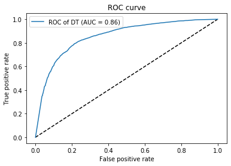

```python
from sklearn.linear_model import LogisticRegression
from sklearn.metrics import roc_curve,auc

dt_lm = LogisticRegression(solver='lbfgs', max_iter=1000)
clf.fit(X_train, y_train)
dt_lm.fit(X_test, y_test)

y_pred_dt = clf.predict_proba(X_test)[:, 1]
fpr_dt, tpr_dt, _ = roc_curve(y_test, y_pred_dt)
roc_auc = auc(fpr_dt, tpr_dt)

plt.figure(1)
plt.plot([0, 1], [0, 1], 'k--')
plt.plot(fpr_dt, tpr_dt, label='ROC of DT (AUC = %0.2f)' % roc_auc)
plt.xlabel('False positive rate')
plt.ylabel('True positive rate')
plt.title('ROC curve')
plt.legend(loc='best')
plt.show()
```

#### ----------------------------------------------------------------

# Export Model

#### ----------------------------------------------------------------

```python
from sklearn.externals import joblib
joblib.dump(clf, 'my_dt_model.pkl', compress=9)
```

```
['my_dt_model.pkl']
```

```python
from sklearn.externals import joblib
model_clone = joblib.load('my_dt_model.pkl')
y_pred_dt = model_clone.predict_proba(X_test)[:, 1]
y_pred_dt
```

```
array([0.74193548, 0.96875   , 0.88461538, ..., 0.4       , 0.23076923,
       0.72      ])
```